# finalfit: Getting started

Ewen Harrison

The `finafit` package brings together the day-to-day functions we use to generate final results tables and plots when modelling.

I spent many years repeatedly manually copying results from R analyses and built these functions to automate our standard healthcare data workflow. It is particularly useful when undertaking a large study involving multiple different regression analyses. When combined with [RMarkdown](https://rmarkdown.rstudio.com/), the reporting becomes entirely automated. Its design follows Hadley Wickham’s [tidy tool manifesto](http://tidyverse.tidyverse.org/articles/manifesto.html).

## Installation and Documentation

Development lives on [GitHub](https://github.com/ewenharrison/finalfit).

You can install the `finalfit` development version from github with:

```r
# install.packages("devtools")
devtools::install_github("ewenharrison/finalfit", ref = "development")
```

It is recommended that this package is used together with `dplyr`, which is a dependent.

Some of the functions require `rstan` and `boot`. These have been left as `Suggests` rather than `Depends` to avoid unnecessary installation. If needed, they can be installed in the normal way:

```r
install.packages("rstan")
install.packages("boot")
```

To [install off-line (or in a Safe Haven)](http://www.datasurg.net/2018/05/05/install-github-package-on-safe-haven-server/), download the zip file and use `devtools::install_local()`.

## Main Features

### 1. Summarise variables/factors by a categorical variable

`summary_factorlist()` is a wrapper used to aggregate any number of explanatory variables by a single **variable of interest**. This is often “Table 1” of a published study. When categorical, the variable of interest can have a maximum of five levels. It uses `Hmisc::summary.formula()`.

```r
library(finalfit)
library(dplyr)

# Load example dataset, modified version of survival::colon
data(colon_s)

# Table 1 - Patient demographics by variable of interest ----
explanatory = c("age", "age.factor", "sex.factor", "obstruct.factor")
dependent = "perfor.factor" # Bowel perforation
colon_s %>%
  summary_factorlist(dependent, explanatory,
  p=TRUE, add_dependent_label=TRUE) -> t1
knitr::kable(t1, row.names=FALSE, align=c("l", "l", "r", "r", "r"))
```

| Dependent: Perforation |  | No | Yes | p |
| --- | --- | --- | --- | --- |
| Age (years) | Mean (SD) | 59.8 (11.9) | 58.4 (13.3) | 0.578 |
| Age | <40 years | 68 (97.1) | 2 (2.9) | 1.000 |
|  | 40-59 years | 334 (97.1) | 10 (2.9) |  |
|  | 60+ years | 500 (97.1) | 15 (2.9) |  |
| Sex | Female | 432 (97.1) | 13 (2.9) | 0.979 |
|  | Male | 470 (97.1) | 14 (2.9) |  |
| Obstruction | No | 715 (97.7) | 17 (2.3) | 0.018 |
|  | Yes | 166 (94.3) | 10 (5.7) |  |

When exported to PDF:

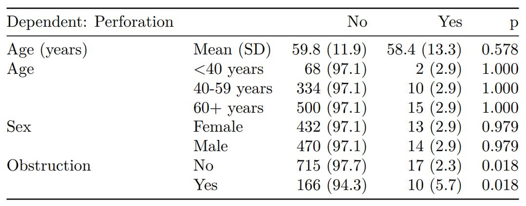

See other options relating to inclusion of missing data, mean vs. median for continuous variables, column vs. row proportions, include a total column etc.

`summary_factorlist()` is also commonly used to summarise any number of variables by an **outcome variable** (say dead yes/no).

```r
# Table 2 - 5 yr mortality ----
explanatory = c("age.factor", "sex.factor", "obstruct.factor")
dependent = 'mort_5yr'
colon_s %>%
  summary_factorlist(dependent, explanatory,
  p=TRUE, add_dependent_label=TRUE) -> t2
knitr::kable(t2, row.names=FALSE, align=c("l", "l", "r", "r", "r"))
```

| Dependent: Mortality 5 year |  | Alive | Died | p |
| --- | --- | --- | --- | --- |
| Age | <40 years | 31 (46.3) | 36 (53.7) | 0.020 |
|  | 40-59 years | 208 (61.4) | 131 (38.6) |  |
|  | 60+ years | 272 (53.4) | 237 (46.6) |  |
| Sex | Female | 243 (55.6) | 194 (44.4) | 0.889 |
|  | Male | 268 (56.1) | 210 (43.9) |  |
| Obstruction | No | 408 (56.7) | 312 (43.3) | 0.189 |
|  | Yes | 89 (51.1) | 85 (48.9) |  |

[figure not shown]

Tables can be knitted to PDF, Word or html documents. We do this in RStudio from a .Rmd document.

### 2. Summarise regression model results in final table format

The second main feature is the ability to create final tables for linear `lm()`, logistic `glm()`, hierarchical logistic `lme4::glmer()` and Cox proportional hazards `survival::coxph()` regression models.

The `finalfit()` “all-in-one” function takes a single dependent variable with a vector of explanatory variable names (continuous or categorical variables) to produce a final table for publication including summary statistics, univariable and multivariable regression analyses. The first columns are those produced by `summary_factorist()`. The appropriate regression model is chosen on the basis of the dependent variable type and other arguments passed.

#### Logistic regression: glm()

Of the form: `glm(depdendent ~ explanatory, family="binomial")`

```r
explanatory = c("age.factor", "sex.factor", "obstruct.factor", "perfor.factor")
dependent = 'mort_5yr'
colon_s %>%
  finalfit(dependent, explanatory) -> t3
knitr::kable(t3, row.names=FALSE, align=c("l", "l", "r", "r", "r", "r"))
```

| Dependent: Mortality 5 year |  | Alive | Died | OR (univariable) | OR (multivariable) |
| --- | --- | --- | --- | --- | --- |
| Age | <40 years | 31 (6.1) | 36 (8.9) | - | - |
|  | 40-59 years | 208 (40.7) | 131 (32.4) | 0.54 (0.32-0.92, p=0.023) | 0.57 (0.34-0.98, p=0.041) |
|  | 60+ years | 272 (53.2) | 237 (58.7) | 0.75 (0.45-1.25, p=0.270) | 0.81 (0.48-1.36, p=0.426) |
| Sex | Female | 243 (47.6) | 194 (48.0) | - | - |
|  | Male | 268 (52.4) | 210 (52.0) | 0.98 (0.76-1.27, p=0.889) | 0.98 (0.75-1.28, p=0.902) |
| Obstruction | No | 408 (82.1) | 312 (78.6) | - | - |
|  | Yes | 89 (17.9) | 85 (21.4) | 1.25 (0.90-1.74, p=0.189) | 1.25 (0.90-1.76, p=0.186) |
| Perforation | No | 497 (97.3) | 391 (96.8) | - | - |
|  | Yes | 14 (2.7) | 13 (3.2) | 1.18 (0.54-2.55, p=0.672) | 1.12 (0.51-2.44, p=0.770) |

When exported to PDF:

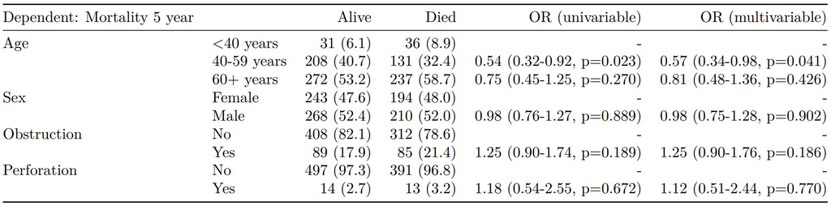

#### Logistic regression with reduced model: glm()

Where a multivariable model contains a subset of the variables included specified in the full univariable set, this can be specified.

```r
explanatory = c("age.factor", "sex.factor", "obstruct.factor", "perfor.factor")
explanatory_multi = c("age.factor", "obstruct.factor")
dependent = 'mort_5yr'
colon_s %>%
  finalfit(dependent, explanatory, explanatory_multi) -> t4
knitr::kable(t4, row.names=FALSE, align=c("l", "l", "r", "r", "r", "r"))
```

| Dependent: Mortality 5 year |  | Alive | Died | OR (univariable) | OR (multivariable) |
| --- | --- | --- | --- | --- | --- |
| Age | <40 years | 31 (6.1) | 36 (8.9) | - | - |
|  | 40-59 years | 208 (40.7) | 131 (32.4) | 0.54 (0.32-0.92, p=0.023) | 0.57 (0.34-0.98, p=0.041) |
|  | 60+ years | 272 (53.2) | 237 (58.7) | 0.75 (0.45-1.25, p=0.270) | 0.81 (0.48-1.36, p=0.424) |
| Sex | Female | 243 (47.6) | 194 (48.0) | - | - |
|  | Male | 268 (52.4) | 210 (52.0) | 0.98 (0.76-1.27, p=0.889) | - |
| Obstruction | No | 408 (82.1) | 312 (78.6) | - | - |
|  | Yes | 89 (17.9) | 85 (21.4) | 1.25 (0.90-1.74, p=0.189) | 1.26 (0.90-1.76, p=0.176) |
| Perforation | No | 497 (97.3) | 391 (96.8) | - | - |
|  | Yes | 14 (2.7) | 13 (3.2) | 1.18 (0.54-2.55, p=0.672) | - |

When exported to PDF:

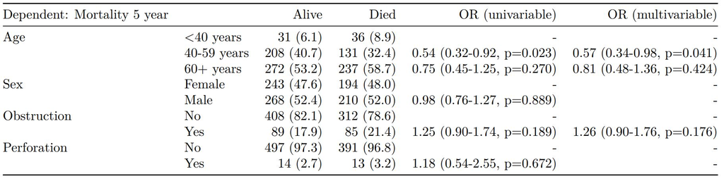

#### Mixed effects logistic regression: lme4::glmer()

Of the form: `lme4::glmer(dependent ~ explanatory + (1 | random_effect), family="binomial")`

Hierarchical/mixed effects/multilevel logistic regression models can be specified using the argument `random_effect`. At the moment it is just set up for random intercepts (i.e. `(1 | random_effect)`, but in the future I’ll adjust this to accommodate random gradients if needed (i.e. `(variable1 | variable2)`.

```r
explanatory = c("age.factor", "sex.factor", "obstruct.factor", "perfor.factor")
explanatory_multi = c("age.factor", "obstruct.factor")
random_effect = "hospital"
dependent = 'mort_5yr'
colon_s %>%
  finalfit(dependent, explanatory, explanatory_multi, random_effect) -> t5
knitr::kable(t5, row.names=FALSE, align=c("l", "l", "r", "r", "r", "r"))
```

| Dependent: Mortality 5 year |  | Alive | Died | OR (univariable) | OR (multilevel) |
| --- | --- | --- | --- | --- | --- |
| Age | <40 years | 31 (6.1) | 36 (8.9) | - | - |
|  | 40-59 years | 208 (40.7) | 131 (32.4) | 0.54 (0.32-0.92, p=0.023) | 0.73 (0.38-1.40, p=0.342) |
|  | 60+ years | 272 (53.2) | 237 (58.7) | 0.75 (0.45-1.25, p=0.270) | 1.01 (0.53-1.90, p=0.984) |
| Sex | Female | 243 (47.6) | 194 (48.0) | - | - |
|  | Male | 268 (52.4) | 210 (52.0) | 0.98 (0.76-1.27, p=0.889) | - |
| Obstruction | No | 408 (82.1) | 312 (78.6) | - | - |
|  | Yes | 89 (17.9) | 85 (21.4) | 1.25 (0.90-1.74, p=0.189) | 1.24 (0.83-1.85, p=0.292) |
| Perforation | No | 497 (97.3) | 391 (96.8) | - | - |
|  | Yes | 14 (2.7) | 13 (3.2) | 1.18 (0.54-2.55, p=0.672) | - |

When exported to PDF:

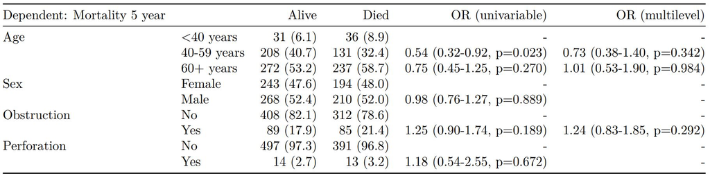

#### Cox proportional hazards: survival::coxph()

Of the form: `survival::coxph(dependent ~ explanatory)`

```r
explanatory = c("age.factor", "sex.factor", "obstruct.factor", "perfor.factor")
dependent = "Surv(time, status)"
colon_s %>%
  finalfit(dependent, explanatory) -> t6
knitr::kable(t6, row.names=FALSE, align=c("l", "l", "r", "r", "r", "r"))
```

| Dependent: Surv(time, status) |  | HR (univariable) | HR (multivariable) |
| --- | --- | --- | --- |
| Age | <40 years | - | - |
|  | 40-59 years | 0.76 (0.53-1.09, p=0.132) | 0.79 (0.55-1.13, p=0.196) |
|  | 60+ years | 0.93 (0.66-1.31, p=0.668) | 0.98 (0.69-1.40, p=0.926) |
| Sex | Female | - | - |
|  | Male | 1.01 (0.84-1.22, p=0.888) | 1.02 (0.85-1.23, p=0.812) |
| Obstruction | No | - | - |
|  | Yes | 1.29 (1.03-1.62, p=0.028) | 1.30 (1.03-1.64, p=0.026) |
| Perforation | No | - | - |
|  | Yes | 1.17 (0.70-1.95, p=0.556) | 1.08 (0.64-1.81, p=0.785) |

When exported to PDF:

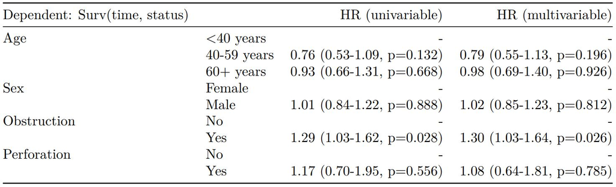

#### Add common model metrics to output

`metrics=TRUE` provides common model metrics. The output is a list of two dataframes. Note chunk specification for output below.

```r
explanatory = c("age.factor", "sex.factor",
  "obstruct.factor", "perfor.factor")
dependent = 'mort_5yr'
colon_s %>%
  finalfit(dependent, explanatory, metrics=TRUE) -> t7
knitr::kable(t7[[1]], row.names=FALSE, align=c("l", "l", "r", "r", "r", "r"))
```

| Dependent: Mortality 5 year |  | Alive | Died | OR (univariable) | OR (multivariable) |
| --- | --- | --- | --- | --- | --- |
| Age | <40 years | 31 (6.1) | 36 (8.9) | - | - |
|  | 40-59 years | 208 (40.7) | 131 (32.4) | 0.54 (0.32-0.92, p=0.023) | 0.57 (0.34-0.98, p=0.041) |
|  | 60+ years | 272 (53.2) | 237 (58.7) | 0.75 (0.45-1.25, p=0.270) | 0.81 (0.48-1.36, p=0.426) |
| Sex | Female | 243 (47.6) | 194 (48.0) | - | - |
|  | Male | 268 (52.4) | 210 (52.0) | 0.98 (0.76-1.27, p=0.889) | 0.98 (0.75-1.28, p=0.902) |
| Obstruction | No | 408 (82.1) | 312 (78.6) | - | - |
|  | Yes | 89 (17.9) | 85 (21.4) | 1.25 (0.90-1.74, p=0.189) | 1.25 (0.90-1.76, p=0.186) |
| Perforation | No | 497 (97.3) | 391 (96.8) | - | - |
|  | Yes | 14 (2.7) | 13 (3.2) | 1.18 (0.54-2.55, p=0.672) | 1.12 (0.51-2.44, p=0.770) |

```r
knitr::kable(t7[[2]], row.names=FALSE, col.names="")
```

| Number in dataframe = 929, Number in model = 894, Missing = 35, AIC = 1230.7, C-statistic = 0.56, H&L = Chi-sq(8) 5.69 (p=0.682) |
| --- |

When exported to PDF:

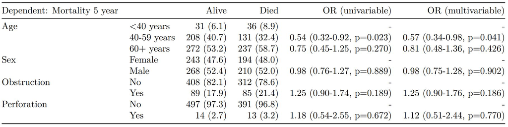

[figure not shown]

#### Combine multiple models into single table

Rather than going all-in-one, any number of subset models can be manually added on to a `summary_factorlist()` table using `finalfit_merge()`. This is particularly useful when models take a long-time to run or are complicated.

Note the requirement for `fit_id=TRUE` in `summary_factorlist()`. `fit2df` extracts, condenses, and add metrics to supported models.

```r
explanatory = c("age.factor", "sex.factor", "obstruct.factor", "perfor.factor")
explanatory_multi = c("age.factor", "obstruct.factor")
random_effect = "hospital"
dependent = 'mort_5yr'

# Separate tables
colon_s %>%
  summary_factorlist(dependent,
  explanatory, fit_id=TRUE) -> example.summary

colon_s %>%
  glmuni(dependent, explanatory) %>%
  fit2df(estimate_suffix=" (univariable)") -> example.univariable

colon_s %>%
  glmmulti(dependent, explanatory) %>%
  fit2df(estimate_suffix=" (multivariable)") -> example.multivariable

colon_s %>%
  glmmixed(dependent, explanatory, random_effect) %>%
  fit2df(estimate_suffix=" (multilevel)") -> example.multilevel

# Pipe together
example.summary %>%
  finalfit_merge(example.univariable) %>%
  finalfit_merge(example.multivariable) %>%
  finalfit_merge(example.multilevel) %>%
  select(-c(fit_id, index)) %>% # remove unnecessary columns
  dependent_label(colon_s, dependent, prefix="") -> t8 # place dependent variable label
knitr::kable(t8, row.names=FALSE, align=c("l", "l", "r", "r", "r", "r", "r"))
```

| Mortality 5 year |  | Alive | Died | OR (univariable) | OR (multivariable) | OR (multilevel) |
| --- | --- | --- | --- | --- | --- | --- |
| Age | <40 years | 31 (46.3) | 36 (53.7) | - | - | - |
|  | 40-59 years | 208 (61.4) | 131 (38.6) | 0.54 (0.32-0.92, p=0.023) | 0.57 (0.34-0.98, p=0.041) | 0.75 (0.39-1.44, p=0.382) |
|  | 60+ years | 272 (53.4) | 237 (46.6) | 0.75 (0.45-1.25, p=0.270) | 0.81 (0.48-1.36, p=0.426) | 1.03 (0.55-1.96, p=0.916) |
| Sex | Female | 243 (55.6) | 194 (44.4) | - | - | - |
|  | Male | 268 (56.1) | 210 (43.9) | 0.98 (0.76-1.27, p=0.889) | 0.98 (0.75-1.28, p=0.902) | 0.80 (0.58-1.11, p=0.180) |
| Obstruction | No | 408 (56.7) | 312 (43.3) | - | - | - |
|  | Yes | 89 (51.1) | 85 (48.9) | 1.25 (0.90-1.74, p=0.189) | 1.25 (0.90-1.76, p=0.186) | 1.23 (0.82-1.83, p=0.320) |
| Perforation | No | 497 (56.0) | 391 (44.0) | - | - | - |
|  | Yes | 14 (51.9) | 13 (48.1) | 1.18 (0.54-2.55, p=0.672) | 1.12 (0.51-2.44, p=0.770) | 1.03 (0.43-2.51, p=0.940) |

When exported to PDF:

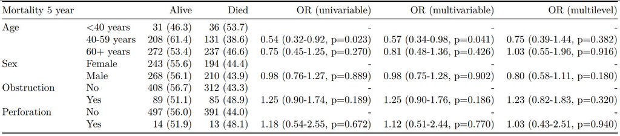

#### Bayesian logistic regression: with `stan`

Our own particular `rstan` models are supported and will be documented in the future. Broadly, if you are running (hierarchical) logistic regression models in [Stan](http://mc-stan.org/users/interfaces/rstan) with coefficients specified as a vector labelled `beta`, then `fit2df()` will work directly on the `stanfit` object in a similar manner to if it was a `glm` or `glmerMod` object.

### 3. Summarise regression model results in plot

Models can be summarized with odds ratio/hazard ratio plots using `or_plot`, `hr_plot` and `surv_plot`.

#### OR plot

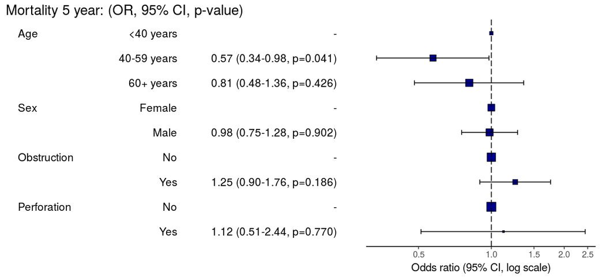

```r
explanatory = c("age.factor", "sex.factor", "obstruct.factor", "perfor.factor")
dependent = 'mort_5yr'
colon_s %>%
  or_plot(dependent, explanatory)
# Previously fitted models (`glmmulti()` or # `glmmixed()`) can be provided directly to `glmfit`
```

#### HR plot

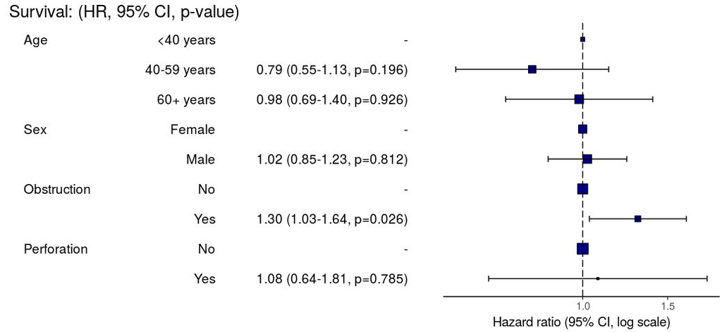

```r
explanatory = c("age.factor", "sex.factor", "obstruct.factor", "perfor.factor")
dependent = "Surv(time, status)"
colon_s %>%
  hr_plot(dependent, explanatory, dependent_label = "Survival")
# Previously fitted models (`coxphmulti`) can be provided directly using `coxfit`
```

#### Kaplan-Meier survival plots

KM plots can be produced using the `library(survminer)`

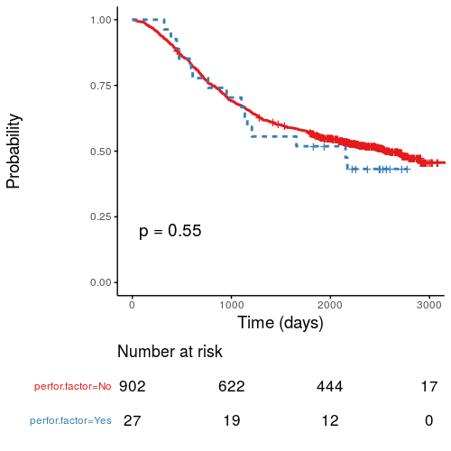

```r
explanatory = c("perfor.factor")
dependent = "Surv(time, status)"
colon_s %>%
  surv_plot(dependent, explanatory,
  xlab="Time (days)", pval=TRUE, legend="none")
```

## Notes

Use `Hmisc::label()` to assign labels to variables for tables and plots.

```r
label(colon_s$age.factor) = "Age (years)"
```

Export dataframe tables directly or to [R Markdown](http://rmarkdown.rstudio.com) [`knitr::kable()`](https://yihui.name/knitr/).

Note wrapper `missing_pattern()` is also useful. Wraps `mice::md.pattern`.

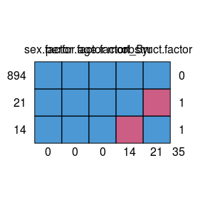

```
#>     sex.factor perfor.factor age.factor mort_5yr obstruct.factor
#> 894          1             1          1        1               1  0
#> 21           1             1          1        1               0  1
#> 14           1             1          1        0               1  1
#>              0             0          0       14              21 35
```

```r
colon_s %>%
  missing_pattern(dependent, explanatory)
```

Development will be on-going, but any input appreciated.